# Isoformic Application to Mouse Neuron Dataset

Izabela Mamede Conceição

Laboratory of Genetics Biochemistry, Universidade Federal de Minas Gerais, Belo Horizonte, Brazil

Lucio Rezende Queiroz

Department of Pathology and Laboratory Medicine, Weill Cornell Medicine, New York, USA

Carlos Augusto da Mata-Machado

Laboratory of Genetics Biochemistry, Universidade Federal de Minas Gerais, Belo Horizonte, Brazil

2024-04-25

## Information

Isoformic uses the differential expression data derived from the transcript counts and Gibbs samples created by pseudo-alignment software such as Salmon (Patro et al., 2017) along with the GENCODE annotation to explore biological function at the isoform-level. Part 1 of this article gives a demonstration of the pipeline upstream of the functions covered in the [introduction vignette](https://luciorq.github.io/isoformic/articles/isoformic_intro.html), such as importing Salmon’s output, Differential Expression and saving DET, DEG and TPM tables; further, in this document’s part 2, we cover Isoformic’s functions. The dataset we chose for this demonstration was [PRJNA984605 BioProject](https://www.ncbi.nlm.nih.gov/bioproject/?term=PRJNA984605), which examined chronic stress in mice (Degroat et al., 2024).

# Part 1 - Importing and Differential Expression

Load dependency packages:

```r
library(isoformic)
library(tidyverse)
library(tximport)
library(DESeq2)
library(apeglm)
library(fishpond)
library(readr)
library(tximeta)
```

## Importing files

Before importing Salmon’s output, we load a sample table which contains sample names and associated metadata.

```r
index_anxiety <- readr::read_csv("ref/index_anxiety.csv",
                                 show_col_types = FALSE)
head(index_anxiety)
```

```
## # A tibble: 6 × 3
##   name        sex    cond
##   <chr>       <chr>  <chr>
## 1 SRR24948924 female stressed
## 2 SRR24948925 male   control
## 3 SRR24948926 female control
## 4 SRR24948927 male   stressed
## 5 SRR24948928 male   control
## 6 SRR24948929 male   stressed
```

The sample names are then used to assign a vector with the Salmon output (`quant.sf` files) locations.

```r
files <- file.path("quant_files/application_quant", paste0(index_anxiety$name,"_quant"), "quant.sf")

names(files) <- index_anxiety$name

all(file.exists(files))
```

```
## [1] TRUE
```

We also set up a transcript-to-gene “dictionary” table (i.e. transcripts information and their parent genes correspondence) thought Isoformic function `make_tx_to_gene()`, using a FASTA file obtained from the GENCODE website - in this example, *Mus musculus* release v34.

```r
txtogene_Mv34 <- isoformic::make_tx_to_gene("ref/gencode.vM34.transcripts.fa.gz", file_type = "fasta")

txtogene_Mv34 <- txtogene_Mv34 |>
  dplyr::select(1,2,5,6,8)

head(txtogene_Mv34)
```

```
## # A tibble: 6 × 5
##   transcript_id        gene_id         transcript_name gene_name transcript_type
##   <chr>                <chr>           <chr>           <chr>     <chr>
## 1 ENSMUST00000193812.2 ENSMUSG0000010… 4933401J01Rik-… 4933401J… TEC
## 2 ENSMUST00000082908.3 ENSMUSG0000006… Gm26206-201     Gm26206   snRNA
## 3 ENSMUST00000162897.2 ENSMUSG0000005… Xkr4-203        Xkr4      protein_coding…
## 4 ENSMUST00000159265.2 ENSMUSG0000005… Xkr4-202        Xkr4      protein_coding…
## 5 ENSMUST00000070533.5 ENSMUSG0000005… Xkr4-201        Xkr4      protein_coding
## 6 ENSMUST00000192857.2 ENSMUSG0000010… Gm18956-201     Gm18956   processed_pseu…
```

## Importing Salmon’s output

Then, `tximport` (Soneson et al., 2015) is used to import Salmon’s output (file paths stored in the `files` vector). We save the TPM table from the new object. First at transcript-level:

```r
tximporteddata <- tximport::tximport(files, type="salmon",
                                     txIn = TRUE,
                                     txOut = TRUE,
                                     countsFromAbundance = "no"
                                     )

txi_counts <- as.data.frame(tximporteddata$abundance) |>
  rownames_to_column(var="transcript_id")

write_csv(txi_counts, "processed_tables/DET_anxiety_counts.csv")
```

And then summarized to gene-level:

```r
tx2gene_filt <- txtogene_Mv34 |>
  select(1,4)

tximporteddata_gene <- tximport::tximport(files, type="salmon",
                                          txIn = TRUE,
                                          txOut = FALSE,
                                          countsFromAbundance = "no",
                                          tx2gene = tx2gene_filt
                                          )

dxi_counts <- as.data.frame(tximporteddata_gene$abundance)

write_csv(dxi_counts, "processed_tables/DEGanxiety_counts.csv")
```

## Differential expression at gene-level (DEG table)

DESeq2 (Love et al., 2014) is used to perform differential expression at the gene-level.

```r
ddsTxi_gene <- DESeq2::DESeqDataSetFromTximport(tximporteddata_gene,
                                                colData = index_anxiety,
                                                design = ~ cond
                                                )

dds_gene <- DESeq2::DESeq(ddsTxi_gene)
```

```r
DESeq2::resultsNames(dds_gene)
```

```
## [1] "Intercept"                "cond_stressed_vs_control"
```

```r
res_dds_gene <- DESeq2::results(dds_gene)

res_shr <- DESeq2::lfcShrink(dds_gene,
                     coef = "cond_stressed_vs_control",
                     type="apeglm"
                     )
```

And to obtain the DEG table:

```r
Male_difexpr <- as.data.frame(res_shr)

Male_difexpr_results <- tibble::rownames_to_column(Male_difexpr)

write.csv(Male_difexpr_results, "processed_tables/Male_DEG_results_dic.csv")
```

## Differential expression at transcript-level (DET)

### Wrangling

Before the differential expression, we wrangle the sample table to include files paths:

```r
files_df <- as.data.frame(files)

files_df <- tibble::rownames_to_column(files_df)

files_df <- dplyr::left_join(files_df,
                      index_anxiety,
                      by = c("rowname"="name")
                      )
```

And then filter for male:

```r
files_male <- files_df |>
  dplyr::filter(sex != "female")

files_male_df <- files_male |>
  dplyr::select(1,2,4)

names(files_male_df) <- c("names", "files", "condition")

se_male <- tximeta::tximeta(files_male_df)

se_male$condition <- factor(se_male$condition, levels = c("control", "stressed"))

y_male <- se_male
```

### Differential expression

To perform transcript-level abundance estimation, we highly recommend the `swish` method implemented in the `fishpond` package (Zhu et al., 2019). In this next code chunk, In this next step, the inferential replicates are scaled, and the RangedSummarizedExperiment is subset to retain only features with ≥100 counts in at least 3 samples.

```r
y_male <- fishpond::scaleInfReps(y_male)

y_male <- fishpond::labelKeep(y_male, minCount = 100, minN = 3)

y_male <- y_male[mcols(y_male)$keep,]

y_male <- fishpond::swish(y_male, x = "condition")
```

To save the DET table, we extract the differential expression data from this RangedSummarizedExperiment object.

```r
library(S4Vectors)
library(tibble)
library(dplyr)

DET_results_male <- S4Vectors::mcols(y_male) |>
  as.data.frame() |>
  dplyr::mutate(gene_id = sapply(gene_id, `[`, 1)) |>
  tibble::rownames_to_column("transcript_id") |>
  tibble::as_tibble()

DET_results_male_f <- dplyr::left_join(
  DET_results_male,
  (txtogene_Mv34 |>
     dplyr::select(transcript_id, gene_name, transcript_type, transcript_name)), by = "transcript_id") |>
  dplyr::select(-tx_name)

head(DET_results_male_f)
```

```
## # A tibble: 6 × 13
##   transcript_id      tx_id gene_id log10mean keep    stat  log2FC  pvalue locfdr
##   <chr>              <int> <chr>       <dbl> <lgl>  <dbl>   <dbl>   <dbl>  <dbl>
## 1 ENSMUST0000016289…  4537 ENSMUS…      2.59 TRUE   32.8   0.727  0.00318  0.178
## 2 ENSMUST0000015926…  4538 ENSMUS…      2.41 TRUE   21.3   0.517  0.0603   0.497
## 3 ENSMUST0000007053…  4539 ENSMUS…      2.30 TRUE   19.5   0.568  0.0863   0.585
## 4 ENSMUST0000002703…  4554 ENSMUS…      1.93 TRUE    3.32  0.0809 0.769    1
## 5 ENSMUST0000015681…  4569 ENSMUS…      1.92 TRUE   -5.27 -0.155  0.642    1
## 6 ENSMUST0000011553…  4571 ENSMUS…      2.55 TRUE  -24.9  -0.250  0.0278   0.342
## # ℹ 4 more variables: qvalue <dbl>, gene_name <chr>, transcript_type <chr>,
## #   transcript_name <chr>
```

```r
write_csv(DET_results_male_f, "processed_tables/swish_DET_male.csv")
```

# Part 2 - Isoformic application

In this section we provide a demonstration of Isoformic (thoroughly explained in the [introduction vignette](https://luciorq.github.io/isoformic/articles/isoformic_intro.html)), applied to [PRJNA984605 BioProject](https://www.ncbi.nlm.nih.gov/bioproject/?term=PRJNA984605), which examined chronic stress in mice (Degroat et al., 2024). The upstream data wrangling is described in part 1.

Load dependency packages:

```r
library(isoformic)
library(tidyverse)
library(tximport)
library(DESeq2)
library(fishpond)
library(readr)
library(tximeta)
library(fs)
library(readr)
library(dplyr)
library(tidyr)
library(stringr)
library(ghibli)
```

## Importing files

Before using Isoformic’s functions, we need to properly set up the data:

### DEG table

After importing the differentially expressed genes (DEGs) table, we merge it with a subset of the dictionary object (`txtogene_Mv34`). We rename columns and create a filtered vector, `DEGs_male_new_names_sig`, to keep only the `gene_name` of features with $|$`log2FC`$|$ $\geq 1$ and `pvalue` $\leq 0.05$.

```r
Male_difexpr_results <- readr::read_csv("processed_tables/Male_difexpr_results_dic.csv",
                                        show_col_types = FALSE)

gene_join <- txtogene_Mv34 |>
  dplyr::select(gene_id, gene_name) |>
  dplyr::distinct()

DEGs_male <- Male_difexpr_results |>
  dplyr::left_join(gene_join, by = c("rowname"="gene_name"))

names(DEGs_male)[2] <- "gene_name"
names(DEGs_male)[4] <- "log2FC"

DEGs_male_new_names_sig <- DEGs_male |>
  dplyr::filter(abs(log2FC) >= 1) |>
  dplyr::filter(pvalue <= 0.05) |>
  dplyr::select(gene_name) |>
  tidyr::drop_na()

DEGs_sig_joined <- DEGs_male_new_names_sig |>
  dplyr::left_join(txtogene_Mv34, by = "gene_name")
```

### TPM table

We import the TPM table, too, and we use the dictionary table (`txtogene_Mv34`) to include a `transcript_name` column.

```r
txi_counts <- readr::read_csv("processed_tables/DET_anxiety_counts.csv",
                              show_col_types = FALSE)

tpm_join <- txtogene_Mv34 |>
  dplyr::select(transcript_id, transcript_name) |>
  dplyr::distinct()

male_counts <- txi_counts |>
  dplyr::left_join(tpm_join, by = c("transcript_id"))
```

### DET table

```r
DET_results_male_f <- readr::read_csv("processed_tables/swish_DET_male.csv",
                                      show_col_types = FALSE)

DETs_male_sig <- DET_results_male_f |>
  dplyr::filter(pvalue < 0.05 & abs(log2FC)>1)
```

## Colors

The following code chunk is used to assign a color to each type of transcript use throughout the pipeline.

```r
fixed_tx_biotypes <- c(
  "gene", "protein_coding", "retained_intron","protein_coding_CDS_not_defined",
  "nonsense_mediated_decay","lncRNA", "processed_pseudogene", "transcribed_unprocessed_pseudogene",
  "unprocessed_pseudogene", "non_stop_decay", "transcribed_unitary_pseudogene", "pseudogene",
  "unitary_pseudogene"
  )

tx_type_color_names <- c(
  "#fb8072", "#a6d854", "#8da0cb", "#fc8d62",
  "#66c2a5", "#e78ac3", "#ffd92f", "#e5c494",
  "#d9d9d9", "#d9d9d9", "#d9d9d9", "#ffffb3",
  "#d9d9d9"
  )

names(tx_type_color_names) <- fixed_tx_biotypes

tx_type_color_names
```

```
##                               gene                     protein_coding
##                          "#fb8072"                          "#a6d854"
##                    retained_intron     protein_coding_CDS_not_defined
##                          "#8da0cb"                          "#fc8d62"
##            nonsense_mediated_decay                             lncRNA
##                          "#66c2a5"                          "#e78ac3"
##               processed_pseudogene transcribed_unprocessed_pseudogene
##                          "#ffd92f"                          "#e5c494"
##             unprocessed_pseudogene                     non_stop_decay
##                          "#d9d9d9"                          "#d9d9d9"
##     transcribed_unitary_pseudogene                         pseudogene
##                          "#d9d9d9"                          "#ffffb3"
##                 unitary_pseudogene
##                          "#d9d9d9"
```

## Log2FC Plot

This plot compares the log2FC of case vs. control from a gene and its transcripts. To make this kind of plot, we first create a single table that combines gene-level and transcript-level differential expression results, using the Isoformic function `join_DEG_DET()`.

```r
DET_results_male_f_sig <- is_deg_sig(DEGs_sig_joined$transcript_name, DET_results_male_f)

DEG_DET_table <- join_DEG_DET(DEGs_male,
                              DET_results_male_f_sig,
                              logfc_cut = 1,
                              pval_cut = 0.05)
head(DEG_DET_table)
```

```
## # A tibble: 6 × 15
##   name     log2FC pvalue id    transcript_type gene_name tx_id gene_id log10mean
##   <chr>     <dbl>  <dbl> <chr> <chr>           <chr>     <dbl> <chr>       <dbl>
## 1 06100…  3.03e-6  0.307 ENSM… gene            0610005C…    NA <NA>           NA
## 2 06100… -3.70e-7  0.614 ENSM… gene            0610006L…    NA <NA>           NA
## 3 06100…  1.19e-5  0.181 ENSM… gene            0610009E…    NA <NA>           NA
## 4 06100… -1.22e-5  0.123 ENSM… gene            0610009L…    NA <NA>           NA
## 5 06100… -4.03e-6  0.690 ENSM… gene            0610010K…    NA <NA>           NA
## 6 06100… -2.44e-7  0.897 ENSM… gene            0610012D…    NA <NA>           NA
## # ℹ 6 more variables: keep <lgl>, stat <dbl>, locfdr <dbl>, qvalue <dbl>,
## #   abs_log2FC <dbl>, significance <chr>
```

Now it is possible to use the function `plot_log2FC()` for any gene in the table. We provide some examples:

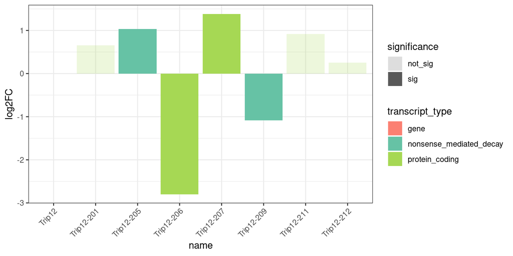

```r
Trip12log2fc <- plot_log2FC(DEG_DET_table, "Trip12") +
  theme(axis.text.x = element_text(angle = 45, vjust = 1, hjust = 1))
Trip12log2fc
```

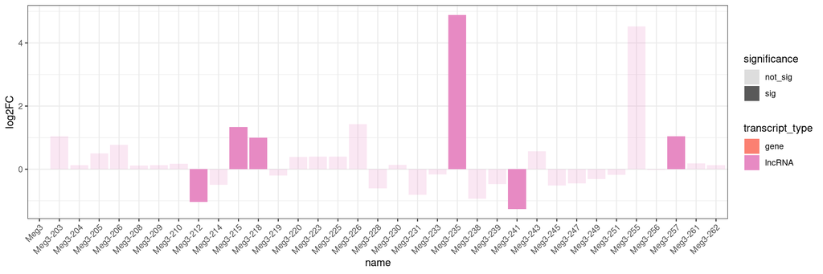

```r
Meg3log2fc <- plot_log2FC(DEG_DET_table, "Meg3") +
  theme(axis.text.x = element_text(angle = 45, vjust = 1, hjust = 1))
Meg3log2fc
```

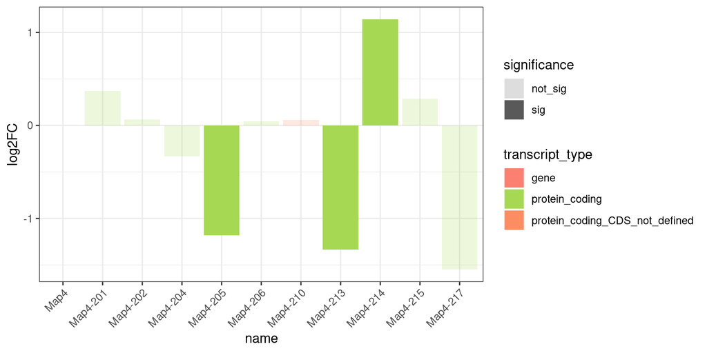

```r
Map4log2fc <- plot_log2FC(DEG_DET_table, "Map4") +
  theme(axis.text.x = element_text(angle = 45, vjust = 1, hjust = 1))
Map4log2fc
```

## Functional Enrichment

To perform functional enrichment, we expand a known `.gmt` for transcript information and enrich each transcript type separately. We chose the M2 gene set from MSigDB and loaded it using `fgsea::gmtPathways()`.

```r
genesets_list <- fgsea::gmtPathways(
  gmt.file = "ref/m2.all.v2023.2.Mm.symbols.gmt.txt"
)

head(str(genesets_list[1:5]))
```

```
## List of 5
##  $ ABBUD_LIF_SIGNALING_1_DN: chr [1:28] "AU021092" "Ahnak" "Alcam" "Ankrd40" ...
##  $ ABBUD_LIF_SIGNALING_1_UP: chr [1:43] "Acaa2" "Aldoc" "Anxa8" "Bcl3" ...
##  $ AFFAR_YY1_TARGETS_DN    : chr [1:276] "A530058N18Rik" "Abhd3" "Adam26a" "Aldh18a1" ...
##  $ AFFAR_YY1_TARGETS_UP    : chr [1:206] "Abat" "Abca1" "Abca3" "Abcc5" ...
##  $ APRELIKOVA_BRCA1_TARGETS: chr [1:48] "Acta1" "Acta2" "Actc1" "Anxa3" ...
```

The function `run_enrichment()` can read in `genesets_list` (the `.gmt` loaded as a list of each biological process) along with the previously created DET table (`DET_results_male_f`), the dictionary table (`txtogene_Mv34`) and an arbitrary p-value cutoff (i.e. a threshold applied to the resulting enrichment table).

```r
enrichment_df <- run_enrichment(
  det_df = DET_results_male_f,
  genesets_list = genesets_list,
  tx_to_gene = txtogene_Mv34,
  pval_cutoff = 0.05
)

head(enrichment_df)
```

```
##                                           pathway         pval         padj
##                                            <char>        <num>        <num>
## 1:                           AFFAR_YY1_TARGETS_UP 1.895770e-02 1.512742e-01
## 2:                        BAKKER_FOXO3_TARGETS_DN 2.385581e-03 4.334894e-02
## 3:               BERENJENO_TRANSFORMED_BY_RHOA_UP 1.699868e-02 1.436544e-01
## 4:             BILANGES_RAPAMYCIN_SENSITIVE_GENES 3.514883e-02 2.248072e-01
## 5: BILANGES_RAPAMYCIN_SENSITIVE_VIA_TSC1_AND_TSC2 1.514239e-05 7.173707e-04
## 6:   BILANGES_SERUM_AND_RAPAMYCIN_SENSITIVE_GENES 4.904667e-17 1.301208e-14
##      log2err         ES       NES  size  leadingEdge     experiment
##        <num>      <num>     <num> <int>       <list>         <char>
## 1: 0.3524879 -0.3029133 -1.341307   266 Ldhb-202.... protein_coding
## 2: 0.4317077 -0.3349644 -1.462075   240 Cobl-208.... protein_coding
## 3: 0.3524879 -0.2606942 -1.242793   705 Ivns1abp.... protein_coding
## 4: 0.3217759 -0.4195251 -1.460497    52 Rpl22-20.... protein_coding
## 5: 0.5933255 -0.4805623 -1.893444   112 Serpinb6.... protein_coding
## 6: 1.0672100 -0.6425331 -2.569961   127 Rbbp6-20.... protein_coding
```

We can plot the resulting enrichment for the productive transcripts:

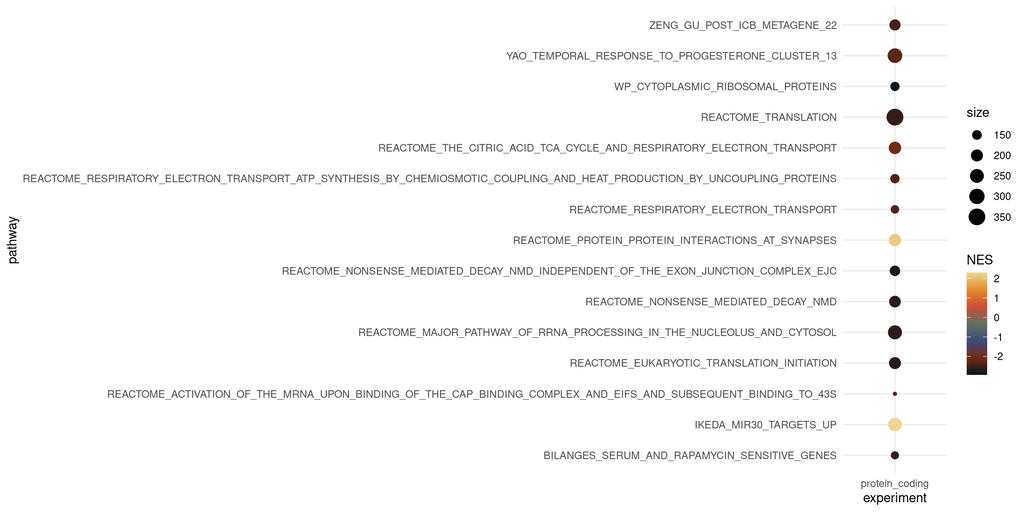

```r
enrichment_df |>
  dplyr::filter((experiment %in% c("protein_coding")) & (abs(NES) > 2)) |>
  dplyr::arrange(padj) |>
  dplyr::slice_head(n = 15) |>
  ggplot2::ggplot(ggplot2::aes(pathway, experiment)) +
  ggplot2::geom_point(ggplot2::aes(col = NES, size = size)) +
  ggplot2::coord_flip() +
  ggplot2::theme_minimal() +
  ghibli::scale_colour_ghibli_c("MononokeMedium")
```

And we can plot, too, the enrichment for the unproductive transcript types:

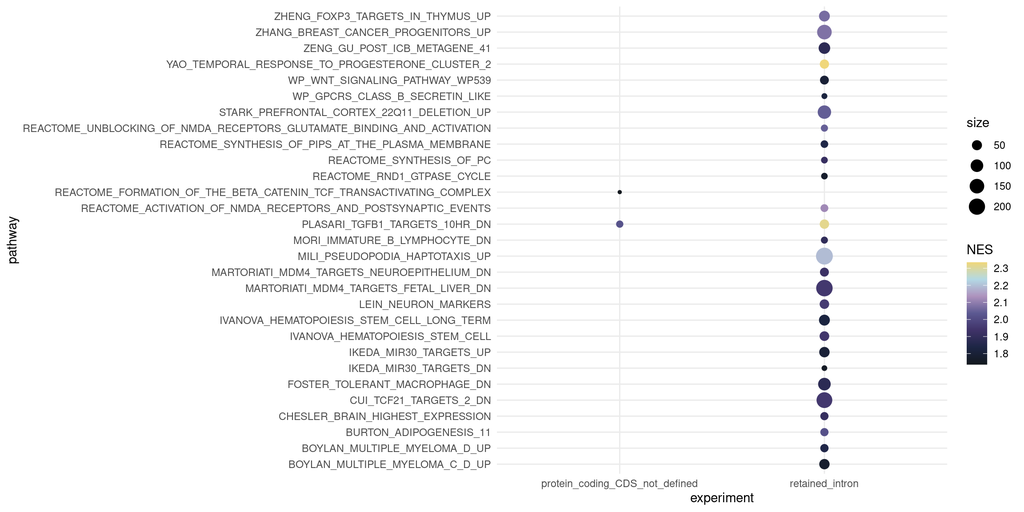

```r
enrichment_df |>
  dplyr::filter((!experiment %in% c("protein_coding", "unproductive")) & (NES) > 1.7) |>
  dplyr::arrange(padj) |>
  dplyr::slice_head(n = 30) |>
  ggplot2::ggplot(ggplot2::aes(pathway, experiment)) +
  ggplot2::geom_point(ggplot2::aes(col = NES, size = size)) +
  ggplot2::coord_flip() +
  ggplot2::theme_minimal() +
  ghibli::scale_colour_ghibli_c("LaputaMedium")
```

# Genomic Context Plot

To visualize and compare transcripts of a given gene, we use the use the `download_reference()` function to download feature annotation and input it in `prepare_exon_annotation()`, along with the gene of interest. Finally, `plot_tx_context()` can be used to create this plot.

```r
library(isoformic)

download_reference(version = "M34", file_type = "gff", organism ="mouse")
```

```
## [1] "data-raw/gencode.vM34.annotation.gff3.gz"
```

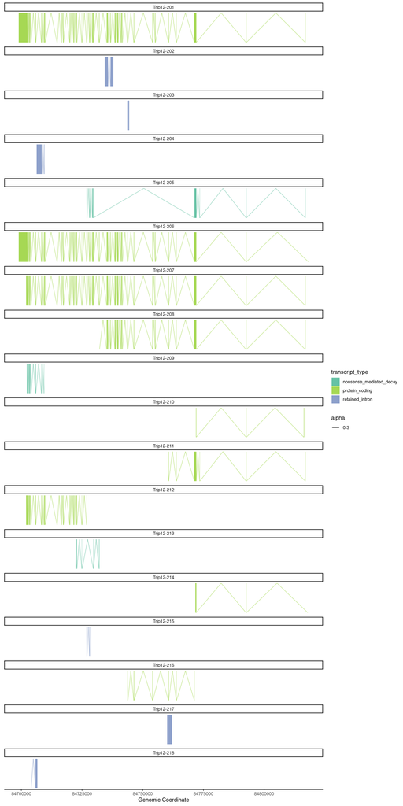

```r
exon_df <- prepare_exon_annotation(
  gene_name = "Trip12",
  file_path = "data-raw/gencode.vM34.annotation.gff3.gz",
  file_type = "gff"
)

tx_to_gene <- txtogene_Mv34

exon_df |>
  plot_tx_context()
```

# References

Degroat, T. J., Wiersielis, K., Denney, K., Kodali, S., Daisey, S., Tollkuhn, J., Samuels, B. A., & Roepke, T. A. (2023). Chronic stress and its effects on behavior, RNA expression of the bed nucleus of the stria terminalis, and the M-current of NPY neurons. *Psychoneuroendocrinology*, *161*, 106920. https://doi.org/10.1016/j.psyneuen.2023.106920

Love, M. I., Huber, W., & Anders, S. (2014). Moderated estimation of fold change and dispersion for RNA-seq data with DESeq2. *Genome Biology*, *15*(12). https://doi.org/10.1186/s13059-014-0550-8

Patro, R., Duggal, G., Love, M. I., Irizarry, R. A., & Kingsford, C. (2017). Salmon provides fast and bias-aware quantification of transcript expression. *Nature Methods*, *14*(4), 417–419. https://doi.org/10.1038/nmeth.4197

Soneson, C., Love, M. I., & Robinson, M. D. (2015). Differential analyses for RNA-seq: transcript-level estimates improve gene-level inferences. *F1000Research*, *4*, 1521. https://doi.org/10.12688/f1000research.7563.1

Zhu, A., Srivastava, A., Ibrahim, J. G., Patro, R., & Love, M. I. (2019). Nonparametric expression analysis using inferential replicate counts. *Nucleic Acids Research*, *47*(18), e105. https://doi.org/10.1093/nar/gkz622